# Malaria Models

An Overview

November 02, 2023

HUB – Roadmap – Library – Model Building

## $\odot$

This document – one of the **core documents** of the `RAMP-Model-Library` – gives a concise overview of the RAMP framework for model building. This is a *conceptual* introduction that avoids going into too much technical detail. We take an overview of topics that have been covered in the past 144 years of malaria epidemiology (counting from Laveran), with a focus on how some of the basic features of malaria epidemiology, transmission dynamics, and control have been incorporated into mathematical models. Each one of the topics we introduce here is introduced in much greater depth in other documents – the links that would take you away from this document look like this: ($\hookrightarrow \boxdot$). Clicking on this link merely reloads this document. Clicking on that symbol later will open another window with a document describing the concept that precedes it.

**Outline**

**1.** `Basics` – We introduce the framework starting with the Parasite *Life-Cycle* and the *Ross-Macdonald Model,* the simplest model you could build that captures the key features of malaria transmission [1]. The framework is designed to be used as part of a state space modeling approach to fit models to data. Working with programs, we need a sound introduction to the basic *metrics* that are used to measure malaria.

**3.** `Spatial Dynamics` – This section describes how the models can be extended to study parasite dispersal in microsimulation models, and in patch-based models for mosquitoes and adults [4–6]

**4.** `Realism` – This tackles a set of issues related to heterogeneity, including exogenous forcing by weather, a large set of issues related to human demographics, and finally *stochasticity.* We also cover the topic of malaria *surveillance.*

**5.** `Malaria Control` – includes a large set of models for medical interventions and vector control that modify transmission.

**6** `Evolution` covers the evolution of drug and insecticide resistance, the evolution of resistance to diagnostics (*e.g.* the spread of parasites with HRP2 deletions), and human genetics.

**7.** `Economics` covers the burden of malaria, poverty and economic development, …

## 1- Basics

### 1.1 Framework

We have developed a comprehensive approach to modeling malaria that does not rely on individual-based simulation [6]. This document introduces malaria epidemiology through a mathematical framework that is modular, flexible, and extensible. The framework has been implemented into two linked software packages: `exDE` ($\hookrightarrow \boxdot$) for solving systems of differential equations describing malaria; and `MicroMoB` for solving systems of difference equations describing malaria, including stochastic models.

Our challenge was to devise a method for building models that are realistic enough and accurate enough to support the needs of malaria programs. Since the needs of malaria programs vary, and since the programs will need to be able to understand the models to participate in the process, and since there is a great deal of uncertainty, we need a framework to build models that can scale complexity and propagate uncertainty. The framework could start with the Ross-Macdonald model, as a way of developing a common understanding and culture within programs that is familiar with the concepts [1]. It will be familiar to some, because is a common starting point for learning about malaria transmission. As we introduce new concepts, we will draw attention to and address its core limitations. We want to introduce a set of algorithms that add realism and complexity so we can build models are realistic enough to suit the needs of a study. We will often need to go several steps beyond the Ross-Macdonald model. When we start adding realism and complexity, we probably won’t know where to stop, so we start with simple and familiar models, and then elaborate until it’s clear we’ve gone too far.

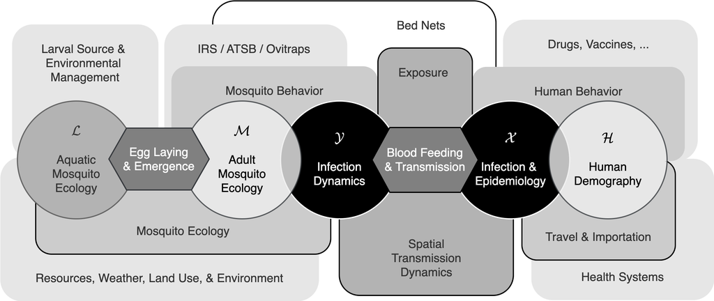

### 1.2 Life-Cycle

The stages of *Plasmodium falciparum* as it goes through its life cycle are an important part of the core knowledge for anyone who works in malaria, as are the details that make *P. vivax* and the other human malaria parasites different. Here, we focus on *P. falciparum.*

The main features of the life cycle are that it the parasites progress through several live stages.

- **The Bloodmeal:** Mosquitoes use vertebrate blood to provision eggs. Adult female mosquitoes search for a vertebrate host. Once they are close, they approach, land, and begin to blood feed. Blood feeding must be understood in its context as a confluence of the activities of humans (and other vertebrate blood hosts) and mosquitoes.
- **Infection** – At least two gametocytes – at least one macrogametocye (female) and one microgametocyte (male) – must be present in the bloodmeal for infection to occur. Flagellated microgametocytes must find the macrogametocyte for fertilization to occur. How those gametocytes find each other in the mosquito midgut is another question [7]. After fertilization, the gamete forms, which develops into the zygote. All of this happens in the mosquito gut in a matrix of partially digested blood.
- The parasites form an ookinete that penetrates the gut of a mosquito and forms an oocyst.
- After several days, the oocyst ruptures releasing large numbers of sporozoites.
- The sporozoites migrate into the salivary glands.
- **The Bite:** – Sporozoites are transmitted in saliva when a mosquito bites a human before blood feeding.
- **Infection** – Some of the sporozoites are sucked back into the mosquito during blood feeding. The remainder must pass through the blood and enter the liver, where they spend about 6 days replicating. Infection herein is defined by parasite replication in a human.
- The parasites emerge from the liver as merozoites and begin a cycle of replication.
- Merozoites infect red blood cells, and roughly 48 hours, the red blood cell bursts, releasing merozoites. Initially, parasite densities increase geometrically. They are detectable in blood around the 10th day after the bite, and peak around the 30th day after the bite. What follows is a long decline in parasite densities and a very long duration of infections with parasite densities fluctuating over time.
- Some of the merozoites are committed to developing into gametocytes. The immature gametocytes sequester in tissues. Mature gametocytes emerge back into circulation after 8-10 day, when they are ready to be taken up in a bloodmeal.

From the point of view of malaria epidemiology and transmission dynamics, some of these details that matter more than others. critical features of this involve the basic features of parasite infections in humans and mosquitoes, including the delays, the duration of infection, infectiousness, and the detectability of parsites.

**Figure:** There are prettier pictures of the life-cycle of *Plasmodium falciparum* but this covers the basics.

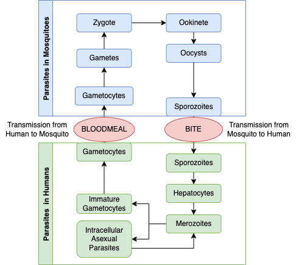

### 1.3 Ross-Macdonald

#### $\oplus$

The *Ross-Macdonald model* does not apply to any particular set of equations [1]. Instead, it’s probably best to think about the Ross-Macdonald model as a few core things:

- A set of parameters describing malaria transmission by mosquitoes, from Macdonald’s analysis of the sporozoite rate [8];
- A formula for the basic reproductive number, $R_0,$ and the associated concept of vectorial capacity [9,10]
- One of several systems of differential or difference equations describing transmission in which:
  - the host infection dynamics are SIS; the waiting time to clear an infection is exponentially or geometrically distributed;
  - vector dynamics are either SI or SEI, and all parameter values are constant;
  - transmission is mass-action.
- A set of metrics describing malaria transmission (see `1.4 Metrics`)
  - the daily entomological inoculation rate (dEIR);
  - the parasite rate, or prevalence of infection (PR);
  - the force of infection (FoI).

A more technical discussion can be found in a vignette describing the mathematical model ($\hookrightarrow \boxdot$)

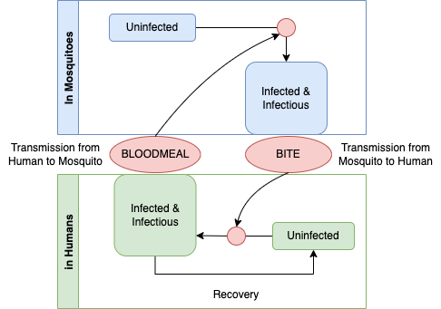

#### Parameters

In Macdonald’s paper on the sporozoite rate, published in 1952 [8], he names several parameters. Later, these parameters were refined slightly by others. Here, we use the notation from this diagram by Smith, *et al.* (2014) [3].

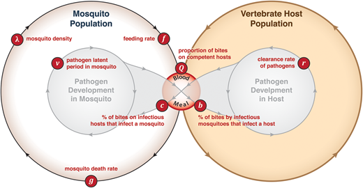

#### Dynamics

**Macdonald’s version**

We can reconstruct the model Macdonald must have used. If we use the parameters we have just defined, and if we let $x$ denote the prevalence of infected humans, $y$ the prevalence of infected mosquitoes, and $z$ the prevalence of infectious mosquitoes; and we let $x_\tau$ and $y_\tau$ denote the values of the variables at time $t-\tau$, then

$$\begin{array}{rl}
\frac{\textstyle{dx}}{\textstyle{dt}} = & mfqbz (1-x) - r x\\
\frac{\textstyle{dy}}{\textstyle{dt}} = & fqcx(m-y) - g y\\
\frac{\textstyle{dz}}{\textstyle{dt}} = & fqcx_\tau e^{-g\nu} (m -
y_\tau) - g z\\
\end{array}$$

In this model, we let $E$ denote the daily EIR, the product of the human biting rate ($ma$, HBR) and the sporozoite rate (SR), which we get from solving the equations at the steady state, and:

$$z \frac{a c x}{g + a c x} e^{-gn}.$$

So

$$\begin{equation}
E = maz = \frac{m a^2cx}{g + acx} e^{-gn}.
\end{equation}$$

Macdonald’s formula for $R_0$ and the formula for vectorial capacity (VC, denoted $V$ in equations) can be derived by considering the EIR as a function of $\kappa = cx$ and taking a limit of their ratio:

$$\begin{equation}
V = \lim_{\kappa \rightarrow 0} ma\frac{z(\kappa)}{\kappa} =
m f^2 q^2 \left. \frac{dz(\kappa)}{d\kappa}\right|_{\kappa=0} =
\frac{m a^2 }{g} e^{-g\nu} =
\lambda \frac{f^2 q^2}{g^2} e^{-g\nu}.
\end{equation}$$

An important quantity is $s=fq/g$, the expected number of human blood meals that a mosquito would take over its lifespan. The right hand side, recapitulated, says that after emergence ($\lambda$), a mosquito must bite a human to become infected ($fq/g$), then survive the EIP ($e^{-g\nu}$), before it becomes infectious and infects humans ($fq/g$).

Macdonald’s formula assumes $c=1$, and it was equivalent to:

$$\begin{equation}
R_0 = \frac{bcV}{r}.
\end{equation}$$

We can use $R_0$ as a threshold condition. If
$$R_0 >1$$
then there is an internal steady state:
$$x
= \frac{\textstyle{R_0-1}}{\textstyle{R_0 + cs}}$$

**An Extensible Version**

If we are to elaborate on the Ross-Macdonald model, adding realism to address policy concerns, as a first step, we need to reformulate the model. When the variables are fractions, it’s difficult to deal with changing denominators. We can, instead, reformulate the model with population densities.

The following system of equations tracks one presented by Aron & May (1982) [14]. We can keep most of the notation, but we let $H$ denote human population density, $M$, the adult mosquito population density. We let $a = fq$:

- $X$ is the density of infected and infectious humans;
- $Y$ is the density of infected mosquitoes;
- $Z$ is the density of infectious mosquitoes;

As before, we let $X_\tau$ and $Y_\tau$ denote the values of the variables at time $t-\tau$.

$$\begin{array}{rl}
\frac{\textstyle{dX}}{\textstyle{dt}} = &
fqb\frac{\textstyle{Z}}{\textstyle{H}} (H-X) - r X\\
\frac{\textstyle{dY}}{\textstyle{dt}} = & fq\frac{\textstyle{c
X}}{\textstyle{H}} (M-Y) - g Y\\
\frac{\textstyle{dZ}}{\textstyle{dt}} = & fq \frac{\textstyle{c
X_\tau}}{\textstyle{H}} e^{-g\nu} (M - Y_\tau) - g Z\\
\end{array}$$

We can get back to Macdonald’s equations with a simple change of variables $x=X/H$; $y=Y/M$; and $z=Z/M$.

### 1.4 Metrics

#### $\oplus$

The Ross-Macdonald model includes a set of metrics [1]. In RAMP, we want to use data describing malaria transmission to guide policy. The metrics that we have described as part of the Ross-Macdonald model are herein called **research metrics,** and we also provide a brief description of some of the metrics used for routine **surveillance**

**Background Reading**

- *Ross, Macdonald, and a theory for the dynamics and control of mosquito-transmitted pathogens* (2012) [1]
- *Measuring malaria endemicity from intense to interrupted transmission.* (2008) [16]
- *Measuring malaria for elimination.* (2009) [17]
- *Measuring changes in Plasmodium falciparum transmission: Precision, accuracy and costs of metrics.* (2014) [18]

#### Research Metrics

- PR
- EIR: the daily EIR is the product of the HBR and the SR
  - HBR - the number of blood meals by vectors, per human, per day
  - SR - the fraction of infectious mosquitoes.
- FoI

#### Surveillance

- CI
- TPR

### 1.5 State Space Modeling

### 1.6 Critique

## 2 Complexity

### $\oplus$

We extend the Ross-Macdonald model to address major limitations of the models for blood feeding, mosquito ecology, and malaria epidemiology.

**Blood Feeding**

The first concept we *must* address is blood feeding. It is the process by which parasites are transmitted, and it is a core non-linearity in models for transmission. Mosquito blood meals are almost certainly *not* distributed evenly among humans, so *heterogeneous exposure* is an important factor to consider in any study. Heterogeneous biting modifies the core dynamics and threshold conditions for parasite persistence. Without a rigorous yet flexible model for blood feeding, it would be difficult to extend the Ross-Macdonald model. Here, we examine *heterogeneous exposure* and *heterogeneous transmission* in some detail.

**Mosquito Ecology**

The second topic is *mosquito ecology.* We start by introducing a basic model for adult mosquito population dynamics after emergence. We will want to consider how weather and vector control can affect mosquito population dynamics, so we introduce models for *aquatic ecology* that address basic concerns about immature mosquito population development and ecology in aquatic habitats. Since aquatic habitats are structured, we need a way of modeling *egg laying* by adult mosquitoes. Notably, models that discuss *weather,* mosquitoes and transmission are handled later, in the section on **Realism,** and *vector control* is discussed in depth in **Control.**

After Macdonald, there was an intense interest in measuring mosquito mortality, which pointed to mosquito parity, and later to mosquito *age* and senescence. We discuss parity and associated models.

If we want to understand mosquitoes, we need to move beyond the basic assumptions of the Ross-Macdonald model and consider the *behavioral states,* and the closely related concept of *resource availability.* We thus introduce *behavioral state models.*

Finally, we discuss the some of the sticky issues that arise when we want to model malaria transmission when there are *multiple vector species* present in an area, including *competition.*

**Malaria Epidemiology**

By itself, malaria epidemiology (in the narrow sense) is extraordinarily complex. The basic dynamics of the Ross-Macdonald model have been extended in various ways to address several important problems. There are some important concerns about the way the Ross-Macdonald model handles infection, which have been addressed through models for the age of infection (*AoI*) or stage of infection (*SoI*), superinfection and the multiplicity of infection (*MoI*). There are some other important concerns about gametocytes, *infectiousness,* and transmission. *Immunity* to malaria develops and modifies almost everything, including *disease* and its presentation, parasite densities and *detection.*

**Human Behavior & Ecology**

Human behavior and ecology play an important role in the dynamics and control of malaria.

**Synthesis**

### 2.1 Malaria Epidemiology

#### $\oplus$

Malaria epidemiology is complex in many ways.

- 13 Ways of Looking at Malaria

#### 2.1.1 Infection

##### -

##### AoI

##### SoI

##### MoI

##### Detection

##### Infectiousness

#### 2.1.2 Treatment & Chemoprotection

#### 2.1.2 Disease

##### -

##### Fever

##### Severe Disease

##### Anemia

#### 2.1.4 Immunity

#### Notes

### 2.2 Mosquitoes

#### -

#### 2.2.1 Blood Feeding

##### -

To ensure mathematical consistency in modeling heterogeneous blood feeding and mixing, we need a blood feeding algorithm that has a few key features:

1. The model of blood feeding should be based on realistic assumptions about mosquito behaviors and physiological constraints;
2. The number of human bites/bloodmeals taken by mosquitoes over any period should be equal to the number of bites/bloodmeals received by humans over that same period.
3. It should not be possible for mosquitoes to blood feed if there are no hosts available.
4. The fraction of bites on humans should be $0$ if there are no humans, and $1$ if humans are the only vertebrate hosts available.
5. Ideally, we would like to be able to modify the model of blood feeding to capture a few key parameters.

**Outline**

##### 2.2.2 Heterogeneous Biting

###### -

Suppose we were in a population where some people got bit by mosquitoes more than others. Many reasons why this could happen have been documented: pregnancy; age; body size; housing quality; living in close proximity to aquatic habitats; elements of breath and sweat that make people more attractive to mosquitoes; spending time outside at dawn or dusk; using repellents or not; using bed nets or not; the number of people in the household. The question for us is how we can understand the effects of heterogeneity on malaria epidemiology, transmission dynamics, and control.

###### Biting Weights

We start with a simple way of computing and describing *relative biting rates,* which we will call $\omega$, assigned to population strata such that the expected dEIR for that stratum is $\omega E$. We let $H_\omega$ be the density of humans in a stratum indexed by the relative biting rate. Everyone belongs to some stratum, so:

$$H = \int_0^\infty H_\omega \; d \omega$$
Similarly, we can let $X_\omega$ denote the density of infected humans in each stratum, so
$$X = \int_0^\infty X_\omega \; d \omega$$
The prevalence of infection is:

$$\frac{\textstyle{X}}{\textstyle{H}} =
\frac{\textstyle{\int_0^\infty X_\omega d
\omega}}{\textstyle{\int_0^\infty H_\omega d \omega}}$$

We want to constrain the distribution such that dEIR is actually the mean. We let $E$ denote the daily EIR.

$$\frac{\textstyle{\int_0^\infty \omega E
\; H_\omega \; d \omega}}{H} = E$$
or

$$\int_0^\infty \omega \; H_\omega \; d
\omega = H$$

We need a practical way of computing $\omega$ in models, and for this, we adopt a very similar concept called a *biting weight,* $v$. We can think of a biting weight as being something like a relative biting rate, but non-normalized. We want to think of the biting weight for a typical member of the population as $1$, but what counts as typical can change if the composition of the population changes.

- Biting weights modify the expected dEIR for a stratum;
- The total biting weight $v$ is, possibly, the product of biting weights associated with many factors;
- We let $H_v = H_\omega$ index the density of the population stratum with total biting weight $v$. The total *availability* of hosts is:

$$\int_0^\infty v \; H_v
\; dv$$

- The relative biting rate is the total biting weight normalized by availability:

$$\omega
= \frac{\textstyle{v}}{\textstyle{\int_0^\infty v \; H_v
\; dv}}$$

- The spatial mixing matrix, $\beta$ in *Spatial Dynamics of Malaria Transmission* is computed using biting weights [6].

###### Dynamics

Heterogeneous biting modifies infection dynamics. To illustrate, we analyze this modified version of the Ross-Macdonald model.

The Ross-Macdonald model computes a threshold condition for parasite persistence. It is based on a concept called the basic reproductive number, $R_0.$ Malaria transmission can be endemic if
$$R_0 > 1.$$

Heterogeneous biting amplifies transmission such that there is a new threshold condition
$$R_0(1 + \alpha) >
1,$$

- Smith, *et al.* (2005) [26] explored the dynamics of several models with heterogeneous biting where $H(\omega)$ was $\Gamma$-distributed, for example.
- Several authors have explored threshold conditions for such models [9,20–25].

##### 2.2.3 Availability

In the Ross-Macdonald model, blood feeding is described by two parameters: an overall blood feeding rate, $f$, and a human fraction, $q$. Humans and mosquitoes interactions behave according to the laws of mass-action. These assumptions are a good place to start, but there are some good reasons to develop a framework to model blood feeding when the availability of hosts is changing.

Blood feeding is an activity that involves mosquitoes searching for and attempting to blood feed on a human. We have already introduced the concept of a biting weight. Here, we would like to use it to formulate a generalized model of blood feeding, based on the concept of mosquito searching and the *availability of blood hosts.* The total availability of humans is:

$$W = \int_0^\infty v H_v \; dv$$
We can lump all the other vertebrate blood hosts together into a single term $O$, and we define the total availability of hosts as:

$$B = W + O^\zeta$$

When $\zeta=1$, the density of other blood hosts scales linearly with total host availability, but it could scale non-linearly. This simple power law is one (of many) ways of representing this scaling.

More generally, we can let

$$B = W + F_O(O)$$

We want to model blood feeding rates and the human fraction as a function of availability, so we let:

$$f = F_f(B)$$

Where $F_f$ is any functional form with the constraint that the blood feeding rate must be zero if no hosts are available,
$$F_f(0) = 0.$$

$$q = W/B$$
Here, we call $F_f$ the functional response.

##### 2.1.3 Environmental Heterogeneity

In there analysis of CDC light trap mosquito catch counts, heterogeneity was partitioned into a frailty term (*e.g.* a biting weight), but there was enormous variability that remained [19]. Here, we define environmental heterogeneity to include all of the other sources of variability in exposure to biting mosquitoes. We note that the standard formula relating the dFoI to the dEIR: $h = b E,$ is consistent with a Poisson distribution. In this model, the daily FoI could be computed for general distribution:

$$h = F_h(E, b)$$
where $b$ could depend on a model, $\cal X$, describing infection dynamics. If we let $b$ have the standard interpretation – the fraction of bites by infectious mosquitoes that would cause an infection in a fully susceptible host – then a *negative binomial* hazard function with one free parameter, $\phi$, is:

$$\begin{equation}
F_h(E, b, \phi) = \frac{\ln \left(1 + bE \phi \right)} {\phi}
\end{equation}$$

Also, see Environmental Heterogeneity.

##### Notes

These notions are endemic in `exDE`

#### 2.2.1 Adults

GeRM

We want to be able to deal with changing mosquito population densities. The following system of equations tracks one presented by Aron & May (1982) [14]. We let $\Lambda$ the emergence rate of adult mosquitoes. The variables are:

- $M$ is the density of mosquitoes;
- $P$ is the density of parous mosquitoes;
- $Y$ is the density of infected mosquitoes;
- $Z$ is the density of infectious mosquitoes;

As before, we let $M_\tau$ and $Y_\tau$ denote the values of the variables at time $t-\tau$.

$$\begin{array}{rl}
\frac{\textstyle{dM}}{\textstyle{dt}} = & \Lambda - g M \\
\frac{\textstyle{dP}}{\textstyle{dt}} = & f (M-P) - g P\\
\frac{\textstyle{dY}}{\textstyle{dt}} = & fq\frac{\textstyle{c
X}}{\textstyle{H}} (M-Y) - g Y\\
\frac{\textstyle{dZ}}{\textstyle{dt}} = & fq \frac{\textstyle{c
X_\tau}}{\textstyle{H}} e^{-g\nu} (M_\tau - Y_\tau) - g Z\\
\end{array}$$

We can get back to Macdonald’s equations with a simple change of variables: $y=Y/M$; and $z=Z/M$.

#### 2.2.2 Aquatic Ecology

##### -

##### -

$$\begin{array}{rl}
\frac{\textstyle{dM}}{\textstyle{dt}} = & \sum_i \alpha_i /2 - g M
\\
\frac{\textstyle{dL_i}}{\textstyle{dt}} = & \chi f p_i M - (\alpha_i
+ \phi_i + \sigma_i L_i) L_i \\
\end{array}$$

##### Egg Laying

**Habitat Search Weights**

$$p_i =
\frac{\textstyle{w_i}}{\textstyle{\sum_i w_i}}$$

#### 2.2.3 Behavioral State Models

GeRM

#### Notes

### 2.4 Human Ecology

#### -

#### 2.4.1 Travel & Mobility

Travel malaria is incorporated by adding a term, $\delta(t)$, called the travel FoI.

$$\frac{\textstyle{dX}}{\textstyle{dt}} =
(F_h(E) + \delta(t))(H-X) - r.X$$

#### 2.4.2 Care Seeking

#### 2.4.3 Births & Deaths

#### 2.4.4 Migration

### Notes

#### -

#### Memory

#### Seasonality

#### Transmission

## 3 Space

Malaria **spatial dynamics** of **connectivity.**

### -

Models for malaria **spatial dynamics** have been formulated in various ways. Here, we discuss *patch-based* metapopulation models, and *point-based* micro-simulation models. We also discuss the general concept of **malaria connectivity.** + Metapopulation Dynamics

- Microsimulation

### 3.1 Microsimulation

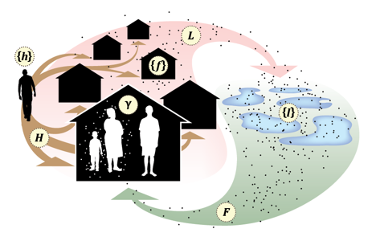

From *Heterogeneity, mixing, and the spatial scales of mosquito-borne pathogen transmission* (PLoS Comp Bio, 2013, Perkins,*et al.*) [4]

Here, we define micro-simulation models as models on point sets, an idea first described by [27]

### 3.2 Metapopulations

### 3.3 Connectivity

### 3.4 Spatial Concepts

## 4 Realism

### 4.1 Blood Feeding

### 4.2 - Mosquitoes

#### -

#### Multiple Vectors

#### Senescence

#### Weather

#### Habitat Dynamics

#### Dispersal

### 4.3 - Humans

#### -

#### Cohort Dynamics & Aging

#### Behavior

#### Stratification

#### Malaria in Pregnancy

### 4.4 - Surveillance

### 4.5 - Stochasticity

## 5 Control

### .

- Medical
  - Diagnostics and Detection
  - Compliance
  - Drugs
  - Vaccines
  - Monoclonal Antibodies
- Vector Control

### 5.1 - Vector Control

#### -

#### IRS

#### Bed Nets

#### ATSB

#### LSM

#### EM

#### GM Mosquitoes

### 5.2 Medical

#### -

#### MDA

#### Case Detection

## 6 Evolution

### -

Evolution of Insecticide Resistance

- Evolution of Drug Resistance
- Diagnostics – HRP2 deletions

### 6.1 - Insecticides

### 6.2 - Drugs

### 6.3 - Diagnostics

### 6.4 - Human Genetics

### 6.5 - Biogeography (?)

## 7 Economics

### -

### 7.1 - Burden

### 7.2 - Poverty

## $\dagger$

**Contributors**

- David L Smith

**References**

1.

Smith DL, Battle KE, Hay SI, Barker CM, Scott TW, McKenzie FE. Ross, Macdonald, and a theory for the dynamics and control of mosquito-transmitted pathogens. PLoS Pathog. 2012;8: e1002588. doi:10.1371/journal.ppat.1002588

2.

Reiner RC Jr, Perkins TA, Barker CM, Niu T, Chaves LF, Ellis AM, et al. A systematic review of mathematical models of mosquito-borne pathogen transmission: 1970-2010. J R Soc Interface. 2013;10: 20120921.

3.

Smith DL, Perkins TA, Reiner RC Jr, Barker CM, Niu T, Chaves LF, et al. Recasting the theory of mosquito-borne pathogen transmission dynamics and control. Trans R Soc Trop Med Hyg. 2014;108: 185–197. doi:10.1093/trstmh/tru026

4.

Perkins TA, Scott TW, Le Menach A, Smith DL. Heterogeneity, mixing, and the spatial scales of mosquito-borne pathogen transmission. PLoS Comput Biol. 2013;9: e1003327.

5.

Citron DT, Guerra CA, Dolgert AJ, Wu SL, Henry JM, Sánchez C HM, et al. Comparing metapopulation dynamics of infectious diseases under different models of human movement. Proc Natl Acad Sci U S A. 2021;118: e2007488118. doi:10.1073/pnas.2007488118

6.

Wu SL, Henry JM, Citron DT, Ssebuliba DM, Nsumba JN, C HMS, et al. Spatial dynamics of malaria transmission. PLOS Computational Biology. 2023;19: e1010684. doi:10.1371/journal.pcbi.1010684

7.

Lawniczak MKN, Eckhoff PA. A computational lens for sexual-stage transmission, reproduction, fitness and kinetics in Plasmodium falciparum. Malar J. 2016;15: 487. doi:10.1186/s12936-016-1538-5

8.

Macdonald G. The analysis of the sporozoite rate. Trop Dis Bull. 1952;49: 569–586. Available: https://www.ncbi.nlm.nih.gov/pubmed/14958825

9.

Smith DL, McKenzie FE, Snow RW, Hay SI. Revisiting the basic reproductive number for malaria and its implications for malaria control. PLoS Biol. 2007;5: e42. doi:10.1371/journal.pbio.0050042

10.

Garrett-Jones C. Prognosis for interruption of malaria transmission through assessment of the mosquito’s vectorial capacity. Nature. 1964;204: 1173–1175. doi:10.1038/2041173a0

11.

Armitage P. A note on the epidemiology of malaria. Trop Dis Bull. 1953;50: 890–892.

12.

Smith DL, McKenzie FE. Statics and dynamics of malaria infection in Anopheles mosquitoes. Malaria J. 2004;3: 13. doi:10.1186/1475-2875-3-13

13.

Macdonald G. The analysis of equilibrium in malaria. Trop Dis Bull. 1952;49: 813–829. Available: https://www.ncbi.nlm.nih.gov/pubmed/12995455

14.

Aron JL, May RM. The population dynamics of malaria. In: Anderson RM, editor. The Population Dynamics of Infectious Diseases: Theory and Applications. Boston, MA: Springer US; 1982. pp. 139–179. doi:10.1007/978-1-4899-2901-3_5

15.

Garrett-Jones C. The human blood index of malaria vectors in relation to epidemiological assessment. Bull World Health Organ. 1964;30: 241–261. Available: https://www.ncbi.nlm.nih.gov/pubmed/14153413

16.

Hay SI, Smith DL, Snow RW. Measuring malaria endemicity from intense to interrupted transmission. Lancet Infect Dis. 2008;8: 369–378. doi:10.1016/S1473-3099(08)70069-0

17.

Smith DL, Smith TA, Hay SI. Measuring malaria for elimination. In: Feachem RGA, Phillips AA, Targett GAT, editors. Shrinking the Malaria Map. San Francisco, CA: University of California, San Francisco; 2009. pp. 108–126. Available: http://www.worldcat.org/title/shrinking-the-malaria-map-a-prospectus-on-malaria-elimination/oclc/421361248

18.

Tusting LS, Bousema T, Smith DL, Drakeley C. Measuring changes in *Plasmodium* *Falciparum* transmission: Precision, accuracy and costs of metrics. Adv Parasitol. 2014;84: 151–208. doi:10.1016/B978-0-12-800099-1.00003-X

19.

Cooper L, Kang SY, Bisanzio D, Maxwell K, Rodriguez-Barraquer I, Greenhouse B, et al. Pareto rules for malaria super-spreaders and super-spreading. Nat Commun. 2019;10: 3939. doi:10.1038/s41467-019-11861-y

20.

Dietz K. Models for vector-borne parasitic diseases. In: Barigozzi C, Levin SA, editors. Vito Volterra Symposium on Mathematical Models in biology. Berlin: Springer-Verlag; 1980. pp. 264–277.

21.

Dye C, Hasibeder G. Population dynamics of mosquito-borne disease: Effects of flies which bite some people more frequently than others. Trans R Soc Trop Med Hyg. 1986;80: 69–77. doi:10.1016/0035-9203(86)90199-9

22.

Dietz K, Hadeler KP. Epidemiological models for sexually transmitted diseases. J Math Biol. 1988;26: 1–25. Available: https://www.ncbi.nlm.nih.gov/pubmed/3351391

23.

Koella JC. On the use of mathematical models of malaria transmission. Acta Trop. 1991;49: 1–25. doi:10.1016/0001-706x(91)90026-g

24.

Lloyd AL, Zhang J, Root AM. Stochasticity and heterogeneity in host–vector models. Journal of the Royal Society, Interface / the Royal Society. 2007;4: 851–863. doi:10.1098/rsif.2007.1064

25.

Lloyd AL, Kitron U, Perkins TA, Vazquez-Prokopec GM, Waller LA. The Basic Reproductive Number for Disease Systems with Multiple Coupled Heterogeneities. Math Biosci. 2019; 108294. doi:10.1016/j.mbs.2019.108294

26.

Smith DL, Dushoff J, Snow RW, Hay SI. The entomological inoculation rate and *Plasmodium* *Falciparum* infection in African children. Nature. 2005;438: 492–495. doi:10.1038/nature04024

27.

Carter R. Spatial simulation of malaria transmission and its control by malaria transmission blocking vaccination. International Journal for Parasitology. 2002;32: 1617–1624. doi:10.1016/S0020-7519(02)00190-X